# R exercise 5: Classification

Kelsey Gonzalez and Laura Werthmann

Due Nov 6, 2019

First we’ll download the necessary packages, libraries and data.

```r
library(tidyverse)
library(rpart)
library(rpart.plot)
library(DMwR2)
library(rsample)
library(adabag)
library(ipred)
library(randomForest)
library(gbm)
library(performanceEstimation)
library(e1071)
library(nnet)


options(scipen = 999)
```

# [REQUIRED]

Exercises on your data set:

## 1. Build a decision tree (regression or classification) and use one ensemble method on your own dataset.

### traing and test data

First, divide the data into 75% data for training, and 25% for test

```r
train_rows = sample(1:nrow(data), 0.75*nrow(data))
train = data[train_rows, ]
test = data[-train_rows, ]
```

```r
m1 <- rpart(
  formula = Life ~ .,
  data    = train,
  cp   = 0.01,
  method  = "anova"
  )
```

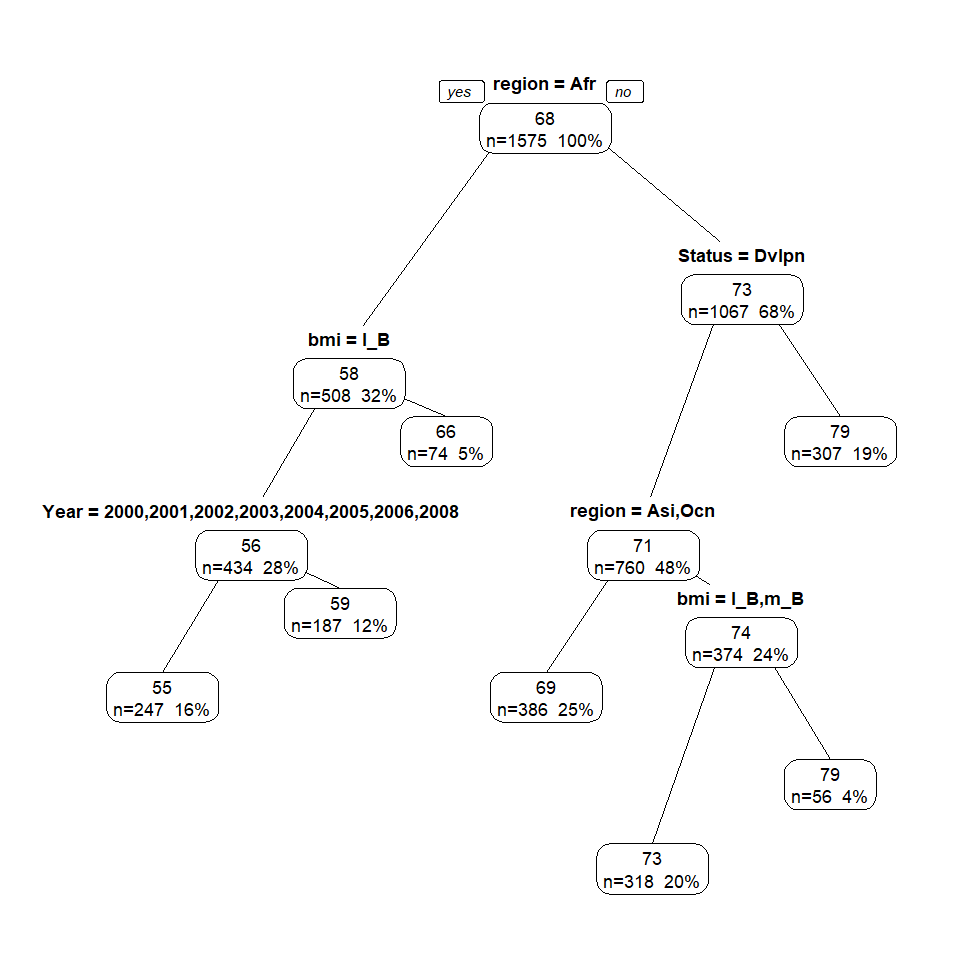

```r
prp(m1, type=1, extra=101, roundint = FALSE)
```

In the plot, y-axis is cross validation error, lower x-axis is cost complexity (α or cp) value, upper x-axis is the number of terminal nodes (tree size) We find diminishing returns after 6 terminal nodes. You may also notice the dashed line which goes through the point tree size= 6.

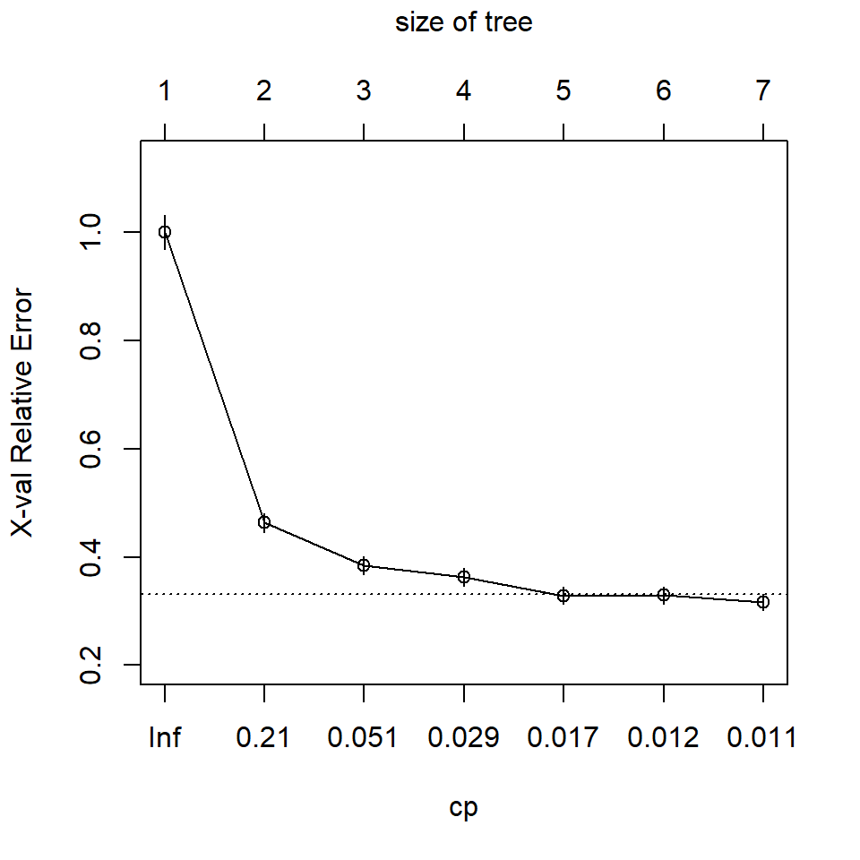

```r
plotcp(m1)
```

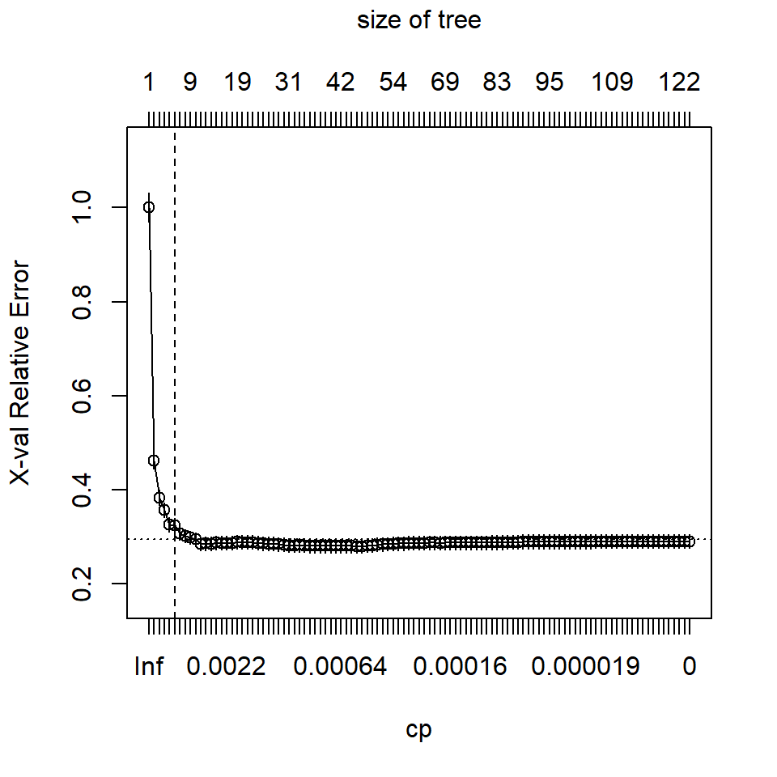

```r
m2 <- rpart(
   formula = Life ~ .,
   data    = train,
   method  = "anova",
   control = list(cp = 0, xval = 10)
 )

plotcp(m2)
abline(v = 6, lty = "dashed")
```

```r
#vertical line at tree size = 6.
```